# Tugas-Pertemuan-2

Widianto Sijabat

2026-08-29

# 1 Data Suhu Bogor 301-400

## 1.1 Import Data

```r
library("forecast")
library("graphics")
library("TTR")
library("TSA")
library("readxl")
library("ggplot2")
```

```r
# Membaca data dari file Excel
data_full <- read_excel("C:/Users/AXIOO/Downloads/data suhu bogor 500 akhir.xlsx")

# Memotong data untuk observasi ke-301 hingga 400
data_bagian <- data_full[301:400, ]
ts_suhu <- ts(data_bagian$`temperature_2m_mean (°C)`)
head(data_bagian)
```

| time | temperature_2m_mean (°C) |
| --- | --- |
| 2026-02-08 | 25.1 |
| 2026-02-09 | 24.1 |
| 2026-02-10 | 24.3 |
| 2026-02-11 | 25.1 |
| 2026-02-12 | 24.7 |
| 2026-02-13 | 24.7 |

```r
summary(ts_suhu)
```

```
##    Min. 1st Qu.  Median    Mean 3rd Qu.    Max.
##   23.60   25.30   26.10   26.03   26.80   27.90
```

## 1.2 Eksplorasi Data

```r
View(data_bagian)
str(data_bagian)
```

```
## tibble [100 × 2] (S3: tbl_df/tbl/data.frame)
##  $ time                    : POSIXct[1:100], format: "2026-02-08" "2026-02-09" ...
##  $ temperature_2m_mean (°C): num [1:100] 25.1 24.1 24.3 25.1 24.7 24.7 25.3 25.3 24.5 25.8 ...
```

```r
dim(data_bagian)
```

```
## [1] 100   2
```

## 1.3 Membuat plot data deret waktu

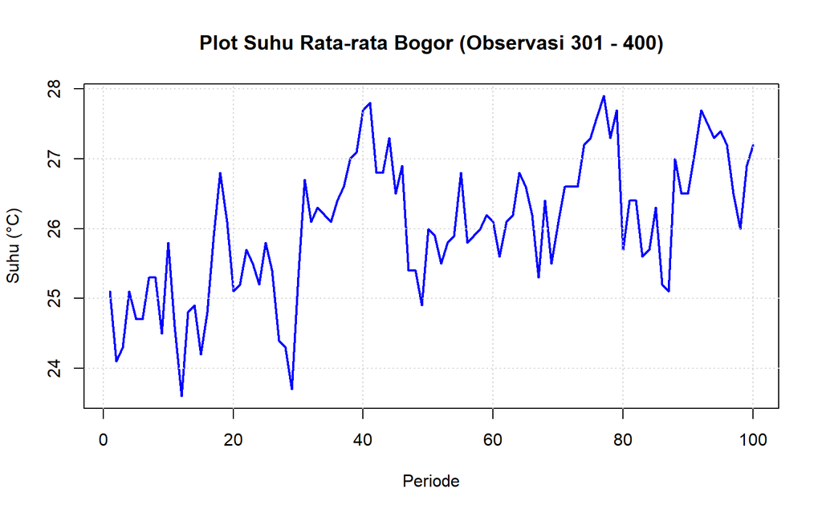

```r
plot.ts(ts_suhu, col = "blue", lwd = 2,
        main = "Plot Suhu Rata-rata Bogor (Observasi 301 - 400)",
        xlab = "Periode", ylab = "Suhu (°C)")
grid()
```

## 1.4 Terapkan metode pemulusan

### 1.4.1 Single Moving Average (SMA)

$$S_t = \frac{1}{m} \sum_{i=t-m+1}^{t}
X_i$$

$$F_t = S_{t-1}, F_{n,h} =
S_n$$

##### 1.4.1.0.1 Menghitung Single Moving Average (SMA)

```r
data.sma <- SMA(ts_suhu, n = 4)
data.sma
```

```
## Time Series:
## Start = 1
## End = 100
## Frequency = 1
##   [1]     NA     NA     NA 24.650 24.550 24.700 24.950 25.000 24.950 25.225
##  [11] 25.050 24.625 24.700 24.475 24.375 24.675 24.950 25.425 25.900 25.975
##  [21] 25.800 25.525 25.375 25.400 25.550 25.475 25.200 24.975 24.450 24.425
##  [31] 25.000 25.450 26.100 26.325 26.175 26.250 26.325 26.525 26.775 27.100
##  [41] 27.400 27.350 27.275 27.175 26.850 26.875 26.525 26.050 25.650 25.425
##  [51] 25.550 25.575 25.800 25.775 26.000 26.075 26.100 26.125 25.975 26.050
##  [61] 25.975 26.000 26.000 26.175 26.425 26.450 26.225 26.125 25.850 25.825
##  [71] 26.150 26.200 26.475 26.750 26.925 27.175 27.500 27.525 27.625 27.150
##  [81] 26.775 26.550 26.025 26.025 26.000 25.700 25.575 25.900 25.950 26.275
##  [91] 26.775 26.950 27.200 27.400 27.475 27.350 27.100 26.775 26.650 26.650
```

##### 1.4.1.0.2 Peramalan

```r
data.ramal <- c(NA, data.sma)
data.ramal # forecast 1 periode ke depan
```

```
##   [1]     NA     NA     NA     NA 24.650 24.550 24.700 24.950 25.000 24.950
##  [11] 25.225 25.050 24.625 24.700 24.475 24.375 24.675 24.950 25.425 25.900
##  [21] 25.975 25.800 25.525 25.375 25.400 25.550 25.475 25.200 24.975 24.450
##  [31] 24.425 25.000 25.450 26.100 26.325 26.175 26.250 26.325 26.525 26.775
##  [41] 27.100 27.400 27.350 27.275 27.175 26.850 26.875 26.525 26.050 25.650
##  [51] 25.425 25.550 25.575 25.800 25.775 26.000 26.075 26.100 26.125 25.975
##  [61] 26.050 25.975 26.000 26.000 26.175 26.425 26.450 26.225 26.125 25.850
##  [71] 25.825 26.150 26.200 26.475 26.750 26.925 27.175 27.500 27.525 27.625
##  [81] 27.150 26.775 26.550 26.025 26.025 26.000 25.700 25.575 25.900 25.950
##  [91] 26.275 26.775 26.950 27.200 27.400 27.475 27.350 27.100 26.775 26.650
## [101] 26.650
```

##### 1.4.1.0.3 Penggabungan data aktual, hasil pemulusan, dan ramalan

```r
data.gab <- cbind(
  aktual = c(ts_suhu, rep(NA, 24)),
  pemulusan = c(data.sma, rep(NA, 24)),
  ramalan = c(data.ramal, rep(data.ramal[length(data.ramal)], 23))
)

data.gab # forecast 24 periode ke depan
```

```
##        aktual pemulusan ramalan
##   [1,]   25.1        NA      NA
##   [2,]   24.1        NA      NA
##   [3,]   24.3        NA      NA
##   [4,]   25.1    24.650      NA
##   [5,]   24.7    24.550  24.650
##   [6,]   24.7    24.700  24.550
##   [7,]   25.3    24.950  24.700
##   [8,]   25.3    25.000  24.950
##   [9,]   24.5    24.950  25.000
##  [10,]   25.8    25.225  24.950
##  [11,]   24.6    25.050  25.225
##  [12,]   23.6    24.625  25.050
##  [13,]   24.8    24.700  24.625
##  [14,]   24.9    24.475  24.700
```

[output cut: 110 more lines]

##### 1.4.1.0.4 Visual SMA

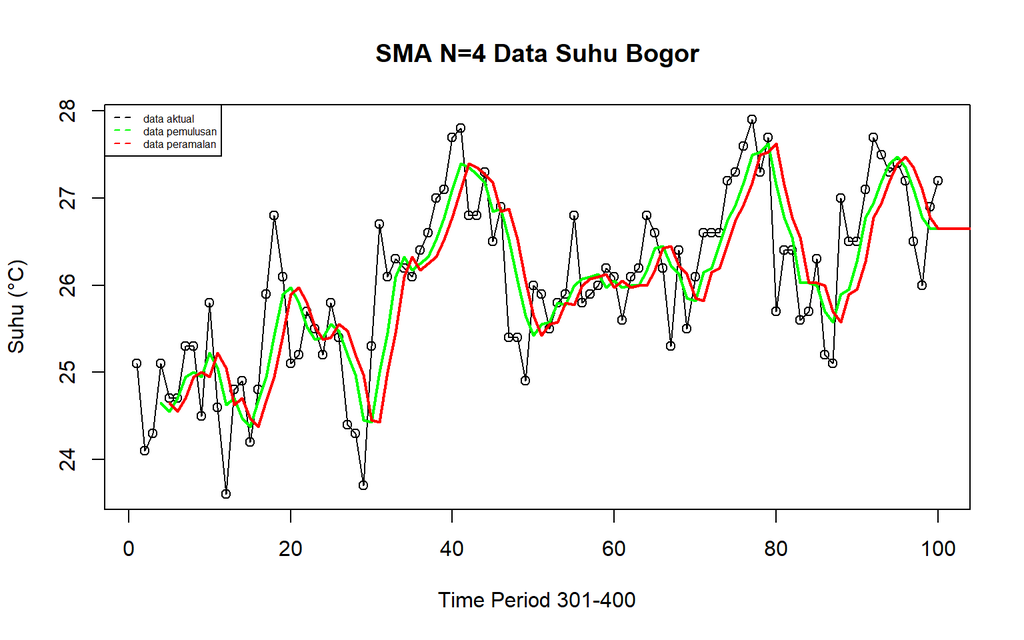

```r
# Plot Data Aktual
ts.plot(ts_suhu, xlab = "Time Period 301-400", ylab = "Suhu (°C)", main = "SMA N=4 Data Suhu Bogor")
points(ts_suhu)

# Garis Pemulusan (kolom 2) dan Ramalan (kolom 3)
lines(data.gab[, 2], col = "green", lwd = 2)
lines(data.gab[, 3], col = "red", lwd = 2)

# Legenda
legend("topleft",
       c("data aktual", "data pemulusan", "data peramalan"),
       lty = 8,
       col = c("black", "green", "red"),
       cex = 0.5)
```

$$SSE = \sum_{t=1}^{n} (y_t -
\hat{y}_t)^2$$

$$MSE = \frac{1}{n} \sum_{t=1}^{n} (y_t -
\hat{y}_t)^2$$

$$MAPE = \frac{1}{n} \sum_{t=1}^{n}
\left|\frac{y_t - \hat{y}_t}{y_t}\right| * 100$$

#### 1.4.1.1 Akurasi Data Latih SMA

```r
#Menghitung nilai keakuratan data latih
train_ma.ts <- ts(ts_suhu[1:80])
error_train.sma <- train_ma.ts - data.ramal[1:length(train_ma.ts)]

SSE_train.sma  <- sum(error_train.sma[5:length(train_ma.ts)]^2)
MSE_train.sma  <- mean(error_train.sma[5:length(train_ma.ts)]^2)
MAPE_train.sma <- mean(abs((error_train.sma[5:length(train_ma.ts)] / train_ma.ts[5:length(train_ma.ts)]) * 100))

akurasi_train.sma <- matrix(c(SSE_train.sma, MSE_train.sma, MAPE_train.sma))
row.names(akurasi_train.sma) <- c("SSE", "MSE", "MAPE")
colnames(akurasi_train.sma) <- c("Akurasi m = 4")
akurasi_train.sma
```

```
##      Akurasi m = 4
## SSE     41.8637500
## MSE      0.5508388
## MAPE     2.2135734
```

Dalam hal ini nilai MAPE data latih pada metode pemulusan SMA sekitar 2%, nilai ini dapat dikategorikan sebagai nilai akurasi yang sangat baik.

#### 1.4.1.2 Akurasi Data UJi SMA

```r
#Menghitung nilai keakuratan data uji
test_ma.ts <- ts(ts_suhu[81:100])
error_test.sma <- test_ma.ts - data.gab[81:100, "ramalan"]

SSE_test.sma  <- sum(error_test.sma^2)
MSE_test.sma  <- mean(error_test.sma^2)
MAPE_test.sma <- mean(abs((error_test.sma / test_ma.ts) * 100))

akurasi_test.sma <- matrix(c(SSE_test.sma, MSE_test.sma, MAPE_test.sma))
row.names(akurasi_test.sma) <- c("SSE", "MSE", "MAPE")
colnames(akurasi_test.sma) <- c("Akurasi m = 4")
akurasi_test.sma
```

```
##      Akurasi m = 4
## SSE       9.655000
## MSE       0.482750
## MAPE      2.257549
```

### 1.4.2 Double Moving Average (DMA)

- **Tahap I:**

$$S_{1,t} = \frac{1}{m} \sum_{i=t-m+1}^{t}
X_i$$

- **Tahap II:**

$$S_{2,t} = \frac{1}{m} \sum_{i=t-m+1}^{t}
S_{1,i}$$

Forecast $h$ langkah ke depan dihitung dengan:

$$F_{2,t,t+h} = A_t + B_t
\,(h)$$

dengan komponen level ($A_t$) dan tren ($B_t$):

$$A_t = 2S_{1,t} - S_{2,t}
\qquad\text{dan}\qquad
B_t = \frac{2}{m-1}\,\big(S_{1,t} - S_{2,t}\big)$$

##### 1.4.2.0.1 Menghitung Double Moving Average (DMA)

```r
dma <- SMA(data.sma, n = 4)
At <- 2 * data.sma - dma
Bt <- 2 / (4 - 1) * (data.sma - dma)
data.dma <- At + Bt
data.ramal2 <- c(NA, data.dma)

t = 1:24
f = c()

for (i in t) {
  f[i] = At[length(At)] + Bt[length(Bt)] * (i)
}

data.gab2 <- cbind(
  aktual = c(ts_suhu, rep(NA, 24)),
  pemulusan1 = c(data.sma, rep(NA, 24)),
  pemulusan2 = c(dma, rep(NA, 24)),
  At = c(At, rep(NA, 24)),
  Bt = c(Bt, rep(NA, 24)),
  ramalan = c(data.ramal2, f[-1])
)

data.gab2
```

```
##        aktual pemulusan1 pemulusan2       At            Bt  ramalan
##   [1,]   25.1         NA         NA       NA            NA       NA
##   [2,]   24.1         NA         NA       NA            NA       NA
##   [3,]   24.3         NA         NA       NA            NA       NA
##   [4,]   25.1     24.650         NA       NA            NA       NA
##   [5,]   24.7     24.550         NA       NA            NA       NA
##   [6,]   24.7     24.700         NA       NA            NA       NA
##   [7,]   25.3     24.950   24.71250 25.18750  1.583333e-01       NA
##   [8,]   25.3     25.000   24.80000 25.20000  1.333333e-01 25.34583
##   [9,]   24.5     24.950   24.90000 25.00000  3.333333e-02 25.33333
##  [10,]   25.8     25.225   25.03125 25.41875  1.291667e-01 25.03333
##  [11,]   24.6     25.050   25.05625 25.04375 -4.166667e-03 25.54792
##  [12,]   23.6     24.625   24.96250 24.28750 -2.250000e-01 25.03958
##  [13,]   24.8     24.700   24.90000 24.50000 -1.333333e-01 24.06250
##  [14,]   24.9     24.475   24.71250 24.23750 -1.583333e-01 24.36667
```

[output cut: 110 more lines]

##### 1.4.2.0.2 Visual DMA

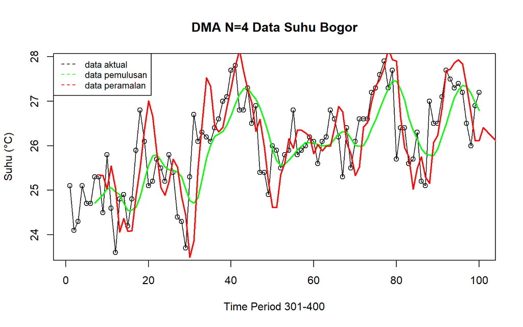

```r
# Plot Data Aktual
ts.plot(ts_suhu, xlab = "Time Period 301-400", ylab = "Suhu (°C)", main = "DMA N=4 Data Suhu Bogor")
points(ts_suhu)

# Garis Pemulusan (kolom 3: pemulusan2/dma) dan Ramalan (kolom 6: ramalan)
lines(data.gab2[, 3], col = "green", lwd = 2)
lines(data.gab2[, 6], col = "red", lwd = 2)

# Legenda
legend("topleft",
       c("data aktual", "data pemulusan", "data peramalan"),
       lty = 8,
       col = c("black", "green", "red"),
       cex = 0.8)
```

#### 1.4.2.1 Akurasi Data Latih DMA

```r
# Menghitung nilai keakuratan data latih DMA
error_train.dma <- train_ma.ts - data.ramal2[1:length(train_ma.ts)]

SSE_train.dma  <- sum(error_train.dma[8:length(train_ma.ts)]^2)
MSE_train.dma  <- mean(error_train.dma[8:length(train_ma.ts)]^2)
MAPE_train.dma <- mean(abs((error_train.dma[8:length(train_ma.ts)] / train_ma.ts[8:length(train_ma.ts)]) * 100))

akurasi_train.dma <- matrix(c(SSE_train.dma, MSE_train.dma, MAPE_train.dma))
row.names(akurasi_train.dma) <- c("SSE", "MSE", "MAPE")
colnames(akurasi_train.dma) <- c("Akurasi m = 4")
akurasi_train.dma
```

```
##      Akurasi m = 4
## SSE     54.1539887
## MSE      0.7418355
## MAPE     2.5246477
```

```r
# Menghitung nilai keakuratan data uji DMA
error_test.dma <- test_ma.ts - data.gab2[81:100, 6]

SSE_test.dma  <- sum(error_test.dma^2)
MSE_test.dma  <- mean(error_test.dma^2)
MAPE_test.dma <- mean(abs((error_test.dma / test_ma.ts) * 100))

akurasi_test.dma <- matrix(c(SSE_test.dma, MSE_test.dma, MAPE_test.dma))
row.names(akurasi_test.dma) <- c("SSE", "MSE", "MAPE")
colnames(akurasi_test.dma) <- c("Akurasi m = 4")
akurasi_test.dma
```

```
##      Akurasi m = 4
## SSE       9.511879
## MSE       0.475594
## MAPE      2.115342
```

Perhitungan akurasi menggunakan data uji menghasilkan nilai MAPE yang kurang dari 10% sehingga nilai akurasi ini dapat dikategorikan sebagai sangat baik.

### 1.4.3 Single Exponential Smoothing (SES)

Nilai pemulusan pada periode ke-t didapat dari persamaan:

$$\tilde{y}_T=\lambda
y_t+(1-\lambda)\tilde{y}_{T-1}$$

Nilai parameter $\lambda$ adalah nilai antara 0 dan 1.

Nilai pemulusan periode ke-t bertindak sebagai nilai ramalan pada periode ke-$(T+\tau)$.

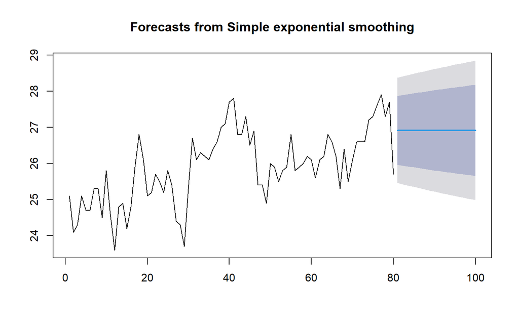

```r
ses.1 <- ses(train_ma.ts, h = 20, alpha = 0.2)
plot(ses.1)
```

```r
ses.1
```

```
##     Point Forecast    Lo 80    Hi 80    Lo 95    Hi 95
##  81       26.91607 25.96653 27.86560 25.46388 28.36825
##  82       26.91607 25.94773 27.88440 25.43512 28.39701
##  83       26.91607 25.92928 27.90285 25.40691 28.42522
##  84       26.91607 25.91117 27.92096 25.37922 28.45291
##  85       26.91607 25.89339 27.93874 25.35201 28.48012
##  86       26.91607 25.87590 27.95623 25.32528 28.50686
##  87       26.91607 25.85871 27.97342 25.29898 28.53315
##  88       26.91607 25.84179 27.99034 25.27311 28.55903
##  89       26.91607 25.82514 28.00700 25.24763 28.58450
##  90       26.91607 25.80873 28.02340 25.22254 28.60959
##  91       26.91607 25.79256 28.03957 25.19782 28.63431
##  92       26.91607 25.77663 28.05551 25.17344 28.65869
##  93       26.91607 25.76091 28.07122 25.14941 28.68273
##  94       26.91607 25.74540 28.08673 25.12569 28.70644
##  95       26.91607 25.73010 28.10203 25.10229 28.72984
##  96       26.91607 25.71499 28.11714 25.07918 28.75295
##  97       26.91607 25.70007 28.13206 25.05636 28.77577
##  98       26.91607 25.68533 28.14680 25.03382 28.79831
##  99       26.91607 25.67077 28.16137 25.01154 28.82059
## 100       26.91607 25.65637 28.17576 24.98952 28.84261
```

##### 1.4.3.0.1 gambar hasil pemulusan

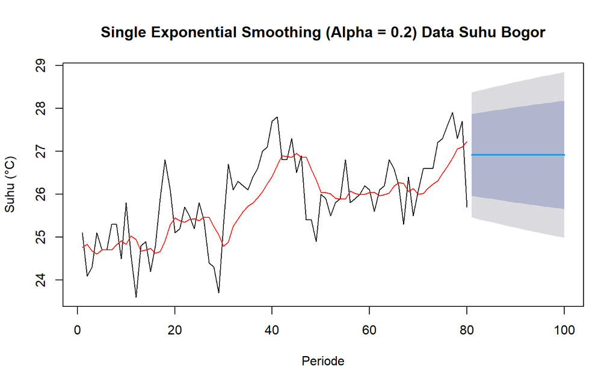

```r
plot(ses.1, ylab = "Suhu (°C)", xlab = "Periode",
     main = "Single Exponential Smoothing (Alpha = 0.2) Data Suhu Bogor")
lines(fitted(ses.1), col = "red")
```

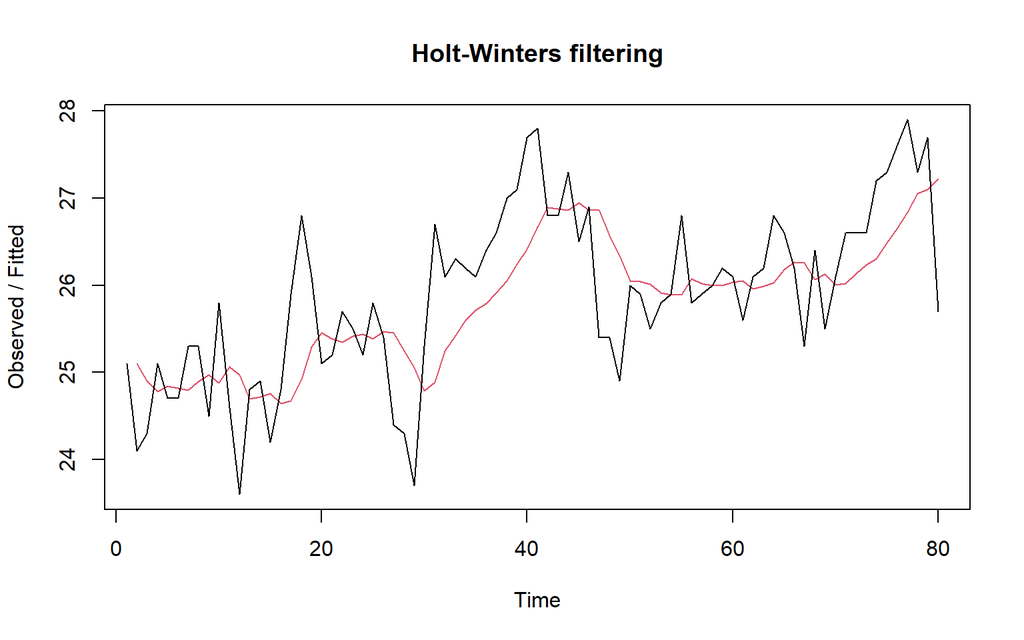

```r
# Pemodelan SES menggunakan fungsi HoltWinters (alpha = 0.2)
ses1 <- HoltWinters(train_ma.ts, gamma = FALSE, beta = FALSE, alpha = 0.2)
plot(ses1)
```

```r
# Ramalan 20 periode ke depan (sesuai jumlah data uji)
ramalan1 <- forecast(ses1, h = 20)
ramalan1
```

```
##     Point Forecast    Lo 80    Hi 80    Lo 95    Hi 95
##  81       26.91607 25.97463 27.85750 25.47626 28.35587
##  82       26.91607 25.95599 27.87615 25.44775 28.38438
##  83       26.91607 25.93770 27.89444 25.41978 28.41235
##  84       26.91607 25.91974 27.91239 25.39232 28.43981
##  85       26.91607 25.90211 27.93002 25.36535 28.46678
##  86       26.91607 25.88477 27.94736 25.33884 28.49329
##  87       26.91607 25.86773 27.96441 25.31277 28.51936
##  88       26.91607 25.85095 27.98118 25.28712 28.54502
##  89       26.91607 25.83444 27.99769 25.26186 28.57027
##  90       26.91607 25.81817 28.01396 25.23698 28.59515
##  91       26.91607 25.80214 28.02999 25.21247 28.61966
##  92       26.91607 25.78634 28.04579 25.18830 28.64383
##  93       26.91607 25.77076 28.06137 25.16447 28.66766
##  94       26.91607 25.75539 28.07675 25.14096 28.69117
##  95       26.91607 25.74021 28.09192 25.11775 28.71438
##  96       26.91607 25.72523 28.10690 25.09484 28.73729
##  97       26.91607 25.71044 28.12169 25.07222 28.75991
##  98       26.91607 25.69582 28.13631 25.04987 28.78226
##  99       26.91607 25.68138 28.15075 25.02778 28.80435
## 100       26.91607 25.66711 28.16502 25.00595 28.82618
```

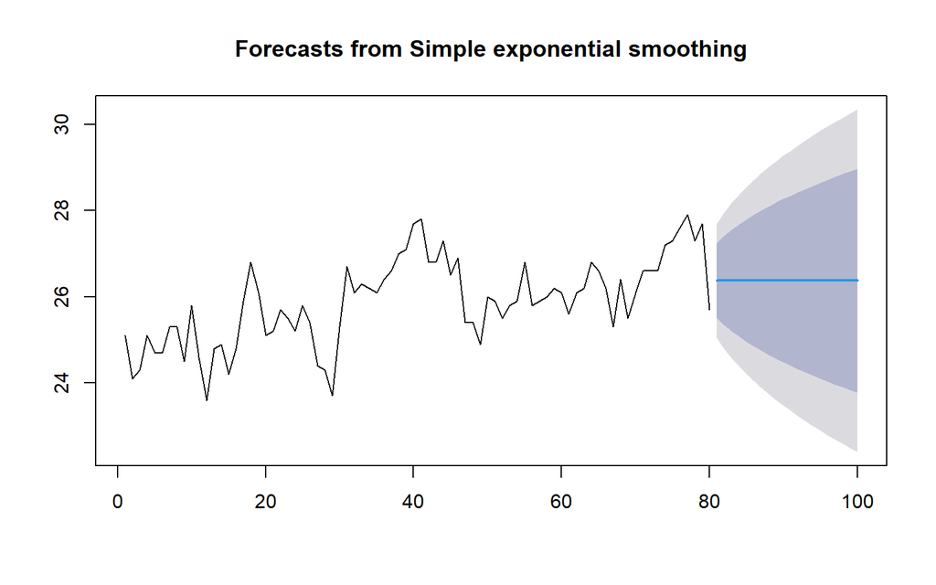

```r
#SES
ses.opt <- ses(train_ma.ts, h = 20, alpha = NULL)
plot(ses.opt)
```

```r
ses.opt
```

```
##     Point Forecast    Lo 80    Hi 80    Lo 95    Hi 95
##  81       26.37426 25.50728 27.24125 25.04832 27.70020
##  82       26.37426 25.34129 27.40724 24.79447 27.95406
##  83       26.37426 25.19851 27.55002 24.57610 28.17243
##  84       26.37426 25.07128 27.67725 24.38152 28.36701
##  85       26.37426 24.95541 27.79311 24.20432 28.54421
##  86       26.37426 24.84832 27.90021 24.04054 28.70799
##  87       26.37426 24.74827 28.00026 23.88752 28.86101
##  88       26.37426 24.65402 28.09451 23.74338 29.00515
##  89       26.37426 24.56468 28.18385 23.60674 29.14179
##  90       26.37426 24.47954 28.26899 23.47654 29.27199
##  91       26.37426 24.39807 28.35046 23.35194 29.39659
##  92       26.37426 24.31983 28.42870 23.23228 29.51625
##  93       26.37426 24.24446 28.50407 23.11701 29.63152
##  94       26.37426 24.17167 28.57686 23.00568 29.74285
##  95       26.37426 24.10120 28.64733 22.89792 29.85061
##  96       26.37426 24.03286 28.71567 22.79339 29.95513
##  97       26.37426 23.96646 28.78207 22.69184 30.05669
##  98       26.37426 23.90183 28.84669 22.59301 30.15552
##  99       26.37426 23.83886 28.90967 22.49670 30.25183
## 100       26.37426 23.77741 28.97112 22.40272 30.34581
```

```r
#Lamda Optimum Holt Winter
HWopt <- HoltWinters(train_ma.ts, gamma = FALSE, beta = FALSE, alpha = NULL)
HWopt
```

```
## Holt-Winters exponential smoothing without trend and without seasonal component.
##
## Call:
## HoltWinters(x = train_ma.ts, alpha = NULL, beta = FALSE, gamma = FALSE)
##
## Smoothing parameters:
##  alpha: 0.6592158
##  beta : FALSE
##  gamma: FALSE
##
## Coefficients:
##       [,1]
## a 26.35295
```

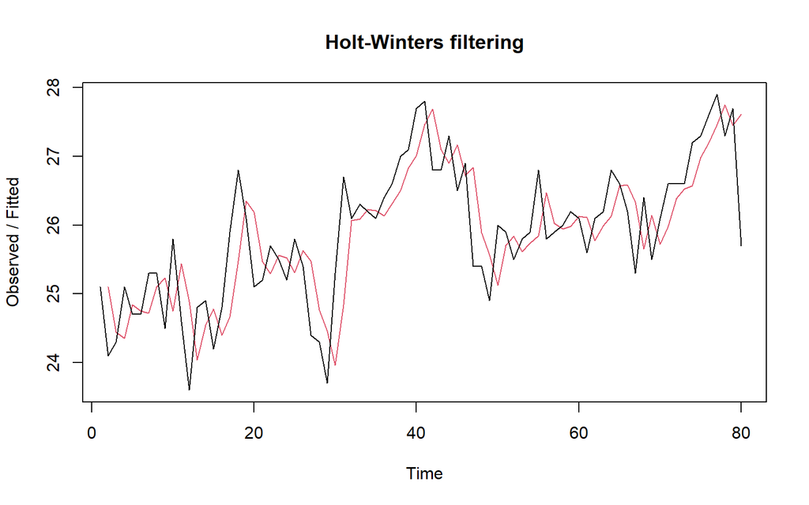

```r
plot(HWopt)
```

```r
#ramalan
ramalanopt <- forecast(HWopt, h = 20)
ramalanopt
```

```
##     Point Forecast    Lo 80    Hi 80    Lo 95    Hi 95
##  81       26.35295 25.48532 27.22057 25.02603 27.67986
##  82       26.35295 25.31376 27.39213 24.76365 27.94224
##  83       26.35295 25.16676 27.53913 24.53884 28.16705
##  84       26.35295 25.03607 27.66982 24.33896 28.36693
##  85       26.35295 24.91723 27.78866 24.15721 28.54869
##  86       26.35295 24.80750 27.89839 23.98939 28.71651
##  87       26.35295 24.70506 28.00084 23.83272 28.87318
##  88       26.35295 24.60862 28.09727 23.68523 29.02066
##  89       26.35295 24.51724 28.18865 23.54548 29.16041
##  90       26.35295 24.43021 28.27568 23.41237 29.29352
##  91       26.35295 24.34694 28.35895 23.28503 29.42086
##  92       26.35295 24.26700 28.43889 23.16276 29.54313
##  93       26.35295 24.19001 28.51589 23.04501 29.66088
##  94       26.35295 24.11566 28.59023 22.93132 29.77458
##  95       26.35295 24.04371 28.66218 22.82128 29.88462
##  96       26.35295 23.97393 28.73196 22.71456 29.99133
##  97       26.35295 23.90615 28.79974 22.61089 30.09500
##  98       26.35295 23.84019 28.86570 22.51001 30.19588
##  99       26.35295 23.77592 28.92998 22.41172 30.29417
## 100       26.35295 23.71321 28.99268 22.31582 30.39007
```

#### 1.4.3.1 Akurasi Data Latih

```r
# Keakuratan Metode
# Pada data training

# SES dengan alpha = 0.2
SSE1 <- ses1$SSE
MSE1 <- ses1$SSE / length(train_ma.ts)
RMSE1 <- sqrt(MSE1)

akurasi1 <- matrix(c(SSE1, MSE1, RMSE1))
row.names(akurasi1) <- c("SSE", "MSE", "RMSE")
colnames(akurasi1) <- c("Akurasi lamda=0.2")
akurasi1
```

```
##      Akurasi lamda=0.2
## SSE         43.1361670
## MSE          0.5392021
## RMSE         0.7343038
```

```r
# SES dengan alpha optimum (HWopt)
SSE2 <- HWopt$SSE
MSE2 <- HWopt$SSE / length(train_ma.ts)
RMSE2 <- sqrt(MSE2)

akurasi2 <- matrix(c(SSE2, MSE2, RMSE2))
row.names(akurasi2) <- c("SSE", "MSE", "RMSE")
colnames(akurasi2) <- c("Akurasi lamda optimum")
akurasi2
```

```
##      Akurasi lamda optimum
## SSE             35.7964944
## MSE              0.4474562
## RMSE             0.6689217
```

#### 1.4.3.2 Akurasi Data Uji

```r
# Pada data testing

# Jumlah observasi uji
n_test <- length(test_ma.ts)

# Error (ramalan - aktual)
e1   <- as.numeric(ramalan1$mean)[1:n_test] - as.numeric(test_ma.ts)
eopt <- as.numeric(ramalanopt$mean)[1:n_test] - as.numeric(test_ma.ts)

# SSE / MSE / RMSE untuk masing-masing model
SSEtesting1  <- sum(e1^2,  na.rm = TRUE)
MSEtesting1  <- mean(e1^2, na.rm = TRUE)
RMSEtesting1 <- sqrt(MSEtesting1)

SSEtestingopt  <- sum(eopt^2,  na.rm = TRUE)
MSEtestingopt  <- mean(eopt^2, na.rm = TRUE)
RMSEtestingopt <- sqrt(MSEtestingopt)

# Tabel ringkas
akurasitesting_SSE <- matrix(c(SSEtesting1, SSEtestingopt),
                             nrow = 2,
                             dimnames = list(c("SSE1 (alpha=0.2)", "SSEopt"), "Nilai"))

akurasitesting_MSE <- matrix(c(MSEtesting1, MSEtestingopt),
                             nrow = 2,
                             dimnames = list(c("MSE1 (alpha=0.2)", "MSEopt"), "Nilai"))

akurasitesting_RMSE <- matrix(c(RMSEtesting1, RMSEtestingopt),
                              nrow = 2,
                              dimnames = list(c("RMSE1 (alpha=0.2)", "RMSEopt"), "Nilai"))

# Menampilkan hasil
akurasitesting_SSE
```

```
##                     Nilai
## SSE1 (alpha=0.2) 13.26402
## SSEopt           11.92366
```

```r
akurasitesting_MSE
```

```
##                      Nilai
## MSE1 (alpha=0.2) 0.6632010
## MSEopt           0.5961831
```

```r
akurasitesting_RMSE
```

```
##                       Nilai
## RMSE1 (alpha=0.2) 0.8143715
## RMSEopt           0.7721290
```

```r
# Mengukur akurasi peramalan SES dengan fungsi accuracy()
accuracy(ramalan1, as.numeric(test_ma.ts))
```

```
##                      ME      RMSE       MAE        MPE     MAPE     MASE
## Training set  0.1149409 0.7389367 0.5822417  0.3684383 2.248972 1.074699
## Test set     -0.3410659 0.8143715 0.6482132 -1.3629844 2.483320 1.196468
##                   ACF1
## Training set 0.4298569
## Test set            NA
```

```r
accuracy(ramalanopt, as.numeric(test_ma.ts))
```

```
##                     ME     RMSE       MAE        MPE     MAPE     MASE
## Training set 0.0240590 0.673142 0.5301864 0.04738682 2.061389 0.978615
## Test set     0.2220544 0.772129 0.6438217 0.75766558 2.418429 1.188363
##                    ACF1
## Training set 0.05285779
## Test set             NA
```

### 1.4.4 Double Exponential Smoothing (DES)

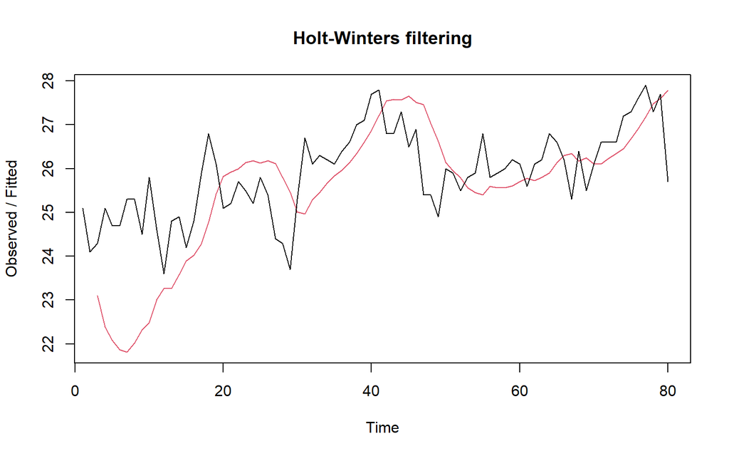

```r
# Pemodelan DES menggunakan fungsi HoltWinters (gamma = FALSE untuk non-musiman)
des.1 <- HoltWinters(train_ma.ts, gamma = FALSE, beta = 0.2, alpha = 0.2)
plot(des.1)
```

```r
# Ramalan
ramalandes1 <- forecast(des.1, h = 20)
ramalandes1
```

```
##     Point Forecast    Lo 80    Hi 80    Lo 95    Hi 95
##  81       27.43894 25.89325 28.98464 25.07501 29.80288
##  82       27.51399 25.92440 29.10358 25.08293 29.94505
##  83       27.58904 25.94159 29.23649 25.06948 30.10860
##  84       27.66409 25.94399 29.38419 25.03342 30.29476
##  85       27.73914 25.93127 29.54700 24.97424 30.50403
##  86       27.81418 25.90352 29.72485 24.89207 30.73630
##  87       27.88923 25.86113 29.91733 24.78752 30.99095
##  88       27.96428 25.80473 30.12383 24.66153 31.26703
##  89       28.03933 25.73505 30.34361 24.51524 31.56342
##  90       28.11438 25.65289 30.57587 24.34985 31.87890
##  91       28.18943 25.55902 30.81983 24.16657 32.21228
##  92       28.26447 25.45420 31.07475 23.96653 32.56242
##  93       28.33952 25.33912 31.33992 23.75081 32.92824
##  94       28.41457 25.21442 31.61472 23.52037 33.30877
##  95       28.48962 25.08067 31.89857 23.27608 33.70315
##  96       28.56467 24.93837 32.19096 23.01873 34.11060
##  97       28.63971 24.78799 32.49144 22.74901 34.53042
##  98       28.71476 24.62992 32.79961 22.46753 34.96200
##  99       28.78981 24.46452 33.11510 22.17485 35.40478
## 100       28.86486 24.29211 33.43761 21.87145 35.85827
```

##### 1.4.4.0.1 Pembanding plot data latih dan data uji

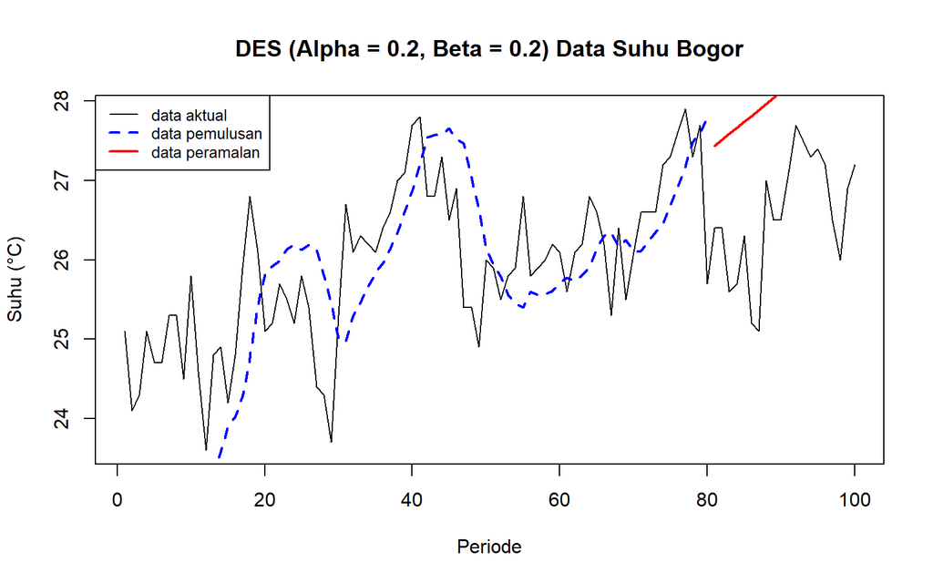

```r
#### Visualisasi DES (Garis Pemulusan & Peramalan)

# Plot Data Aktual
plot(ts_suhu, xlab = "Periode", ylab = "Suhu (°C)", main = "DES (Alpha = 0.2, Beta = 0.2) Data Suhu Bogor")

# Garis Pemulusan/Fitted (Biru Putus-putus) dan Ramalan (Merah)
lines(des.1$fitted[, 1], lty = 2, col = "blue", lwd = 2)
lines(ramalandes1$mean, col = "red", lwd = 2)

# Legenda
legend("topleft",
       c("data aktual", "data pemulusan", "data peramalan"),
       col = c("black", "blue", "red"),
       lty = c(1, 2, 1),
       lwd = c(1, 2, 2),
       cex = 0.8)
```

##### 1.4.4.0.2 Untuk mendapatkan nilai parameter optimum dari DES, argumen `alpha` dan `beta` dapat dibuat `NULL` seperti berikut.

```r
# Pemodelan DES dengan nilai alpha dan beta optimum (gamma = FALSE)
des.opt <- HoltWinters(train_ma.ts, gamma = FALSE)
des.opt
```

```
## Holt-Winters exponential smoothing with trend and without seasonal component.
##
## Call:
## HoltWinters(x = train_ma.ts, gamma = FALSE)
##
## Smoothing parameters:
##  alpha: 0.8704677
##  beta : 0.1590195
##  gamma: FALSE
##
## Coefficients:
##        [,1]
## a 25.969761
## b -0.177185
```

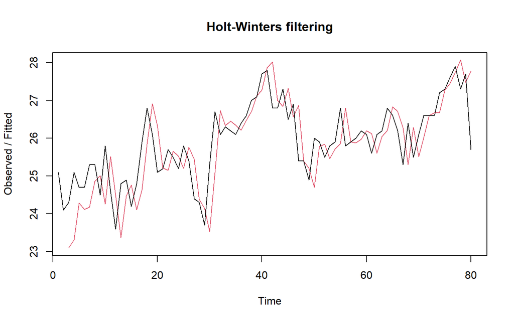

```r
plot(des.opt)
```

```r
# Peramalan 20 periode ke depan (sesuai jumlah data uji)
ramalandesopt <- forecast(des.opt, h = 20)
ramalandesopt
```

```
##     Point Forecast    Lo 80    Hi 80     Lo 95    Hi 95
##  81       25.79258 24.80746 26.77770 24.285964 27.29919
##  82       25.61539 24.21601 27.01477 23.475229 27.75555
##  83       25.43821 23.63940 27.23701 22.687173 28.18924
##  84       25.26102 23.06103 27.46102 21.896421 28.62562
##  85       25.08384 22.47457 27.69310 21.093306 29.07437
##  86       24.90665 21.87716 27.93614 20.273449 29.53985
##  87       24.72947 21.26743 28.19151 19.434733 30.02420
##  88       24.55228 20.64469 28.45987 18.576142 30.52842
##  89       24.37510 20.00869 28.74151 17.697248 31.05294
##  90       24.19791 19.35934 29.03649 16.797949 31.59787
##  91       24.02073 18.69670 29.34475 15.878333 32.16312
##  92       23.84354 18.02091 29.66617 14.938597 32.74849
##  93       23.66636 17.33214 30.00058 13.979003 33.35371
##  94       23.48917 16.63057 30.34777 12.999848 33.97849
##  95       23.31199 15.91642 30.70755 12.001449 34.62252
##  96       23.13480 15.18990 31.07970 10.984127 35.28548
##  97       22.95762 14.45122 31.46401  9.948205 35.96703
##  98       22.78043 13.70058 31.86028  8.894003 36.66686
##  99       22.60325 12.93820 32.26829  7.821831 37.38466
## 100       22.42606 12.16426 32.68786  6.731993 38.12013
```

#### 1.4.4.1 Akurasi Data Latih DES

```r
# Akurasi Data Training DES

# DES dengan alpha = 0.2 dan beta = 0.2
ssedes.train1 <- des.1$SSE
msedes.train1 <- ssedes.train1 / length(train_ma.ts)
sisaandes1    <- ramalandes1$residuals
head(sisaandes1)
```

```
## Time Series:
## Start = 1
## End = 6
## Frequency = 1
## [1]       NA       NA 1.200000 2.712000 2.613120 2.829491
```

```r
mapedes.train1 <- sum(abs(sisaandes1[3:length(train_ma.ts)] / train_ma.ts[3:length(train_ma.ts)]) * 100) / length(train_ma.ts)

akurasides.1 <- matrix(c(ssedes.train1, msedes.train1, mapedes.train1))
row.names(akurasides.1) <- c("SSE", "MSE", "MAPE")
colnames(akurasides.1)  <- c("Akurasi alpha=0.2 dan beta=0.2")
akurasides.1
```

```
##      Akurasi alpha=0.2 dan beta=0.2
## SSE                      121.272955
## MSE                        1.515912
## MAPE                       3.590553
```

```r
# DES Optimum
ssedes.opt <- des.opt$SSE
msedes.opt <- ssedes.opt / length(train_ma.ts)
sisaandesopt <- ramalandesopt$residuals
head(sisaandesopt)
```

```
## Time Series:
## Start = 1
## End = 6
## Frequency = 1
## [1]        NA        NA 1.2000000 1.7893331 0.4179889 0.5824971
```

```r
mapedes.opt <- sum(abs(sisaandesopt[3:length(train_ma.ts)] / train_ma.ts[3:length(train_ma.ts)]) * 100) / length(train_ma.ts)

akurasides.opt <- matrix(c(ssedes.opt, msedes.opt, mapedes.opt))
row.names(akurasides.opt) <- c("SSE", "MSE", "MAPE")
colnames(akurasides.opt)  <- c("Akurasi DES Optimum")
akurasides.opt
```

```
##      Akurasi DES Optimum
## SSE           45.9515512
## MSE            0.5743944
## MAPE           2.2414258
```

#### 1.4.4.2 Akurasi Data Uji DES

```r
selisihdes1 <- as.numeric(ramalandes1$mean) - as.numeric(test_ma.ts)
selisihdes1
```

```
##  [1] 1.0389423 1.1139906 1.9890389 1.9640871 1.4391354 2.6141837 2.7892320
##  [8] 0.9642803 1.5393286 1.6143769 1.0894252 0.5644734 0.8395217 1.1145700
## [15] 1.0896183 1.3646666 2.1397149 2.7147632 1.8898115 1.6648598
```

```r
selisihdesopt <- as.numeric(ramalandesopt$mean) - as.numeric(test_ma.ts)
selisihdesopt
```

```
##  [1] -0.6074236 -0.7846086 -0.1617936 -0.4389786 -1.2161636 -0.2933486
##  [7] -0.3705336 -2.4477186 -2.1249036 -2.3020886 -3.0792736 -3.8564586
## [13] -3.8336436 -3.8108286 -4.0880136 -4.0651986 -3.5423836 -3.2195686
## [19] -4.2967536 -4.7739386
```

```r
SSEtestingdes1  <- sum(selisihdes1^2)
MSEtestingdes1  <- SSEtestingdes1 / length(test_ma.ts)
MAPEtestingdes1 <- sum(abs(selisihdes1 / as.numeric(test_ma.ts)) * 100) / length(test_ma.ts)

SSEtestingdesopt  <- sum(selisihdesopt^2)
MSEtestingdesopt  <- SSEtestingdesopt / length(test_ma.ts)
MAPEtestingdesopt <- sum(abs(selisihdesopt / as.numeric(test_ma.ts)) * 100) / length(test_ma.ts)

akurasitestingdes <- matrix(c(SSEtestingdes1, MSEtestingdes1, MAPEtestingdes1,
                              SSEtestingdesopt, MSEtestingdesopt, MAPEtestingdesopt),
                            nrow = 3, ncol = 2)

row.names(akurasitestingdes) <- c("SSE", "MSE", "MAPE")
colnames(akurasitestingdes)  <- c("des ske1", "des opt")
akurasitestingdes
```

```
##       des ske1    des opt
## SSE  57.518342 169.689823
## MSE   2.875917   8.484491
## MAPE  5.992330   9.148663
```

### 1.4.5 Perbandingan SES vs DES

```r
MSEfull <- matrix(c(MSEtesting1, MSEtestingopt,
                    MSEtestingdes1, MSEtestingdesopt),
                  nrow = 2, ncol = 2)

row.names(MSEfull) <- c("ske 1", "ske opt")
colnames(MSEfull)  <- c("ses", "des")
MSEfull
```

```
##               ses      des
## ske 1   0.6632010 2.875917
## ske opt 0.5961831 8.484491
```

### 1.4.6 Winter Aditif

```r
# 1. Membuat objek time series dengan frekuensi musiman
train_hw.ts <- ts(ts_suhu[1:80], frequency = 7)

# 2. Pemulusan dengan winter aditif (Parameter Tebakan Manual)
winter1 <- HoltWinters(train_hw.ts, alpha = 0.2, beta = 0.1, gamma = 0.1, seasonal = "additive")
winter1$fitted
```

```
## Time Series:
## Start = c(2, 1)
## End = c(12, 3)
## Frequency = 7
##               xhat    level         trend       season
##  2.000000 25.01156 24.84082  0.0044217687  0.166326531
##  2.142857 24.43659 24.90293  0.0101904762 -0.476530612
##  2.285714 25.74644 24.92580  0.0114587755  0.809183673
##  2.428571 24.89111 24.94797  0.0125299537 -0.069387755
##  2.571429 24.67531 24.90228  0.0067077258 -0.233673469
##  2.714286 24.38831 24.69392 -0.0147984967 -0.290816327
##  2.857143 24.84980 24.76146 -0.0065646477  0.094897959
##  3.000000 24.94878 24.76494 -0.0055605613  0.189401361
##  3.142857 24.11763 24.60962 -0.0205361489 -0.471457415
##  3.285714 25.53214 24.72556 -0.0068887205  0.813468386
##  3.428571 24.70004 24.79224  0.0004684806 -0.092676667
##  3.571429 24.93547 25.21270  0.0424677729 -0.319698360
##  3.714286 25.29596 25.48808  0.0657582852 -0.257880930
##  3.857143 25.67540 25.51465  0.0618391807  0.098914305
##  4.000000 25.66323 25.48140  0.0523312088  0.129499010
##  4.142857 25.17729 25.54109  0.0530665130 -0.416867701
##  4.285714 26.56112 25.65870  0.0595207603  0.842897191
##  4.428571 25.55361 25.44600  0.0322984451  0.075320503
##  4.571429 25.33826 25.52757  0.0372261578 -0.226536311
##  4.714286 25.34205 25.57714  0.0384609411 -0.273557348
##  4.857143 25.50770 25.42720  0.0196199697  0.060882417
##  5.000000 25.33318 25.20528 -0.0045340022  0.132440227
##  5.142857 24.44586 24.87411 -0.0371976558 -0.391050712
##  5.285714 25.72163 25.00774 -0.0201148069  0.734007930
##  5.428571 25.27778 25.18330 -0.0005474044  0.095031353
##  5.571429 25.14149 25.34719  0.0158969972 -0.221597178
##  5.714286 25.28494 25.59479  0.0390671492 -0.348921234
##  5.857143 25.83851 25.81687  0.0573684089 -0.035733470
##  6.000000 25.99092 25.92654  0.0625982932  0.001785612
##  6.142857 25.81901 26.07095  0.0707798532 -0.322719316
##  6.285714 27.19661 26.29793  0.0863996026  0.812277540
##  6.428571 26.58828 26.34501  0.0824674730  0.160808960
##  6.571429 26.49360 26.52982  0.0927017915 -0.128916570
##  6.714286 26.70491 26.86380  0.1168297210 -0.275716195
##  6.857143 27.32356 27.19965  0.1387314627 -0.014813933
```

[output cut: 23 more lines]

```
## 10.285714 26.83886 26.29727  0.0214294307  0.520161179
## 10.428571 26.34734 26.19093  0.0086521958  0.147763884
## 10.571429 25.81964 25.99011 -0.0122946902 -0.158179895
## 10.714286 25.94475 26.09389 -0.0006874296 -0.148453347
## 10.857143 25.84224 26.00425 -0.0095824035 -0.152431780
## 11.000000 26.07214 26.04622 -0.0044271659  0.030349495
## 11.142857 25.98232 26.14737  0.0061299420 -0.171178889
## 11.285714 26.76457 26.27703  0.0184835972  0.469052239
## 11.428571 26.34177 26.26260  0.0151922268  0.063976340
## 11.571429 26.37005 26.44944  0.0323568040 -0.111750852
## 11.714286 26.53471 26.66779  0.0509558735 -0.184033242
## 11.857143 26.87225 26.93180  0.0722616594 -0.131810830
## 12.000000 27.37501 27.20961  0.0928166067  0.072577927
## 12.142857 27.25698 27.28743  0.0913164573 -0.121764268
## 12.285714 28.02341 27.46735  0.1001768525  0.455886758
```

```r
xhat1 <- winter1$fitted[, 1]

# 3. Pemulusan dengan winter aditif (Parameter Optimum)
winter1.opt <- HoltWinters(train_hw.ts, alpha = NULL, beta = NULL, gamma = NULL, seasonal = "additive")
winter1.opt
```

```
## Holt-Winters exponential smoothing with trend and additive seasonal component.
##
## Call:
## HoltWinters(x = train_hw.ts, alpha = NULL, beta = NULL, gamma = NULL,     seasonal = "additive")
##
## Smoothing parameters:
##  alpha: 0.4859654
##  beta : 0
##  gamma: 0.4230173
##
## Coefficients:
##            [,1]
## a  26.558058301
## b   0.004421769
## s1  0.240099805
## s2  0.265160676
## s3  0.165998722
## s4  0.043717177
## s5  0.047011441
## s6  0.144273015
## s7 -0.282312118
```

```r
winter1.opt$fitted
```

```
## Time Series:
## Start = c(2, 1)
## End = c(12, 3)
## Frequency = 7
##               xhat    level       trend      season
##  2.000000 25.01156 24.84082 0.004421769  0.16632653
##  2.142857 24.51330 24.98541 0.004421769 -0.47653061
##  2.285714 25.79697 24.98337 0.004421769  0.80918367
##  2.428571 24.92429 24.98926 0.004421769 -0.06938776
##  2.571429 24.60683 24.83609 0.004421769 -0.23367347
##  2.714286 24.06483 24.35122 0.004421769 -0.29081633
##  2.857143 24.81223 24.71291 0.004421769  0.09489796
##  3.000000 24.99345 24.75999 0.004421769  0.22904551
##  3.142857 23.90382 24.37882 0.004421769 -0.47942239
##  3.285714 25.63302 24.81875 0.004421769  0.80984207
##  3.428571 24.81744 24.95292 0.004421769 -0.13990401
##  3.571429 25.47261 25.92080 0.004421769 -0.45260507
##  3.714286 26.10357 26.23011 0.004421769 -0.13095616
##  3.857143 25.86523 25.74683 0.004421769  0.11398283
##  4.000000 25.48890 25.42797 0.004421769  0.05651266
##  4.142857 25.25485 25.53498 0.004421769 -0.28455127
##  4.285714 26.53085 25.65853 0.004421769  0.86789636
##  4.428571 25.31182 25.01621 0.004421769  0.29119539
##  4.571429 24.94610 25.25787 0.004421769 -0.31618299
##  4.714286 25.13811 25.48287 0.004421769 -0.34917861
##  4.857143 25.10234 25.12859 0.004421769 -0.03066888
##  5.000000 24.84994 24.74310 0.004421769  0.10241457
##  5.142857 23.96187 24.18869 0.004421769 -0.23124387
##  5.285714 25.42633 24.84340 0.004421769  0.57850850
##  5.428571 25.86855 25.46678 0.004421769  0.39734687
##  5.571429 25.37062 25.58368 0.004421769 -0.21748546
##  5.714286 25.53449 26.03975 0.004421769 -0.50967692
##  5.857143 26.16687 26.36758 0.004421769 -0.20513511
##  6.000000 26.19630 26.33951 0.004421769 -0.14763430
##  6.142857 26.50707 26.44292 0.004421769  0.05972621
##  6.285714 27.35239 26.49251 0.004421769  0.85546238
##  6.428571 26.77777 26.32568 0.004421769  0.44767472
##  6.571429 26.47572 26.48669 0.004421769 -0.01539507
##  6.714286 26.72553 27.08607 0.004421769 -0.36496580
##  6.857143 27.39740 27.61265 0.004421769 -0.21967589
```

[output cut: 23 more lines]

```
## 10.285714 26.83443 26.56232 0.004421769  0.26768609
## 10.428571 26.65648 26.25843 0.004421769  0.39362410
## 10.571429 25.63333 25.60365 0.004421769  0.02525234
## 10.714286 26.15637 25.98065 0.004421769  0.17129580
## 10.857143 25.39212 25.66610 0.004421769 -0.27840247
## 11.000000 26.05190 26.01453 0.004421769  0.03294667
## 11.142857 26.33286 26.28531 0.004421769  0.04313316
## 11.285714 26.55370 26.41955 0.004421769  0.12973152
## 11.428571 26.54956 26.44647 0.004421769  0.09866358
## 11.571429 26.96337 26.76699 0.004421769  0.19196179
## 11.714286 26.96799 26.93500 0.004421769  0.02857127
## 11.857143 27.12650 27.24655 0.004421769 -0.12447713
## 12.000000 27.78342 27.62687 0.004421769  0.15212940
## 12.142857 27.50201 27.39637 0.004421769  0.10122070
## 12.285714 27.64123 27.49700 0.004421769  0.13979861
```

```r
xhat1.opt <- winter1.opt$fitted[, 1]
```

##### 1.4.6.0.1 Peramalan

```r
forecast1     <- predict(winter1, n.ahead = 20)
forecast1.opt <- predict(winter1.opt, n.ahead = 20)
forecast1
```

```
## Time Series:
## Start = c(12, 4)
## End = c(15, 2)
## Frequency = 7
##            fit
##  [1,] 27.28919
##  [2,] 27.17291
##  [3,] 27.16516
##  [4,] 27.26809
##  [5,] 27.43796
##  [6,] 27.33877
##  [7,] 27.74882
##  [8,] 27.66515
##  [9,] 27.54887
## [10,] 27.54112
## [11,] 27.64405
## [12,] 27.81392
## [13,] 27.71473
## [14,] 28.12478
## [15,] 28.04111
## [16,] 27.92483
## [17,] 27.91708
## [18,] 28.02001
## [19,] 28.18988
## [20,] 28.09069
```

```r
forecast1.opt
```

```
## Time Series:
## Start = c(12, 4)
## End = c(15, 2)
## Frequency = 7
##            fit
##  [1,] 26.80258
##  [2,] 26.83206
##  [3,] 26.73732
##  [4,] 26.61946
##  [5,] 26.62718
##  [6,] 26.72886
##  [7,] 26.30670
##  [8,] 26.83353
##  [9,] 26.86301
## [10,] 26.76827
## [11,] 26.65041
## [12,] 26.65813
## [13,] 26.75981
## [14,] 26.33765
## [15,] 26.86448
## [16,] 26.89397
## [17,] 26.79923
## [18,] 26.68137
## [19,] 26.68908
## [20,] 26.79077
```

##### 1.4.6.0.2 Plot Deret Waktu

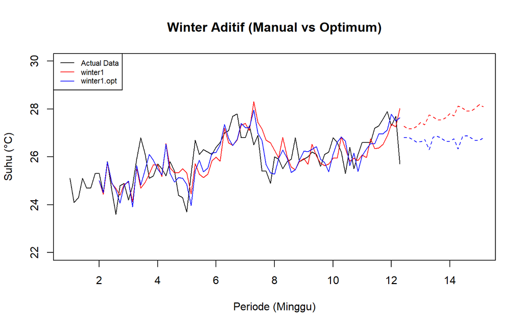

```r
# Plot time series Winter Aditif
plot(train_hw.ts, main = "Winter Aditif (Manual vs Optimum)", type = "l", col = "black",
     xlim = c(1, 15), ylim = c(22, 30), xlab = "Periode (Minggu)", ylab = "Suhu (°C)")
lines(xhat1, type = "l", col = "red")
lines(xhat1.opt, type = "l", col = "blue")
lines(forecast1, type = "l", col = "red", lty = 2)
lines(forecast1.opt, type = "l", col = "blue", lty = 2)
legend("topleft", c("Actual Data", expression(paste(winter1)),
                   expression(paste(winter1.opt))), cex = 0.7,
       col = c("black", "red", "blue"), lty = 1)
```

#### 1.4.6.1 Akurasi Data Latih

```r
# Akurasi data training Winter Aditif

SSE1 <- winter1$SSE
MSE1 <- winter1$SSE / length(train_hw.ts)
RMSE1 <- sqrt(MSE1)
akurasi1 <- matrix(c(SSE1, MSE1, RMSE1))
row.names(akurasi1) <- c("SSE", "MSE", "RMSE")
colnames(akurasi1) <- c("Akurasi")
akurasi1
```

```
##         Akurasi
## SSE  53.7554261
## MSE   0.6719428
## RMSE  0.8197212
```

```r
SSE1.opt <- winter1.opt$SSE
MSE1.opt <- winter1.opt$SSE / length(train_hw.ts)
RMSE1.opt <- sqrt(MSE1.opt)
akurasi1.opt <- matrix(c(SSE1.opt, MSE1.opt, RMSE1.opt))
row.names(akurasi1.opt) <- c("SSE1.opt", "MSE1.opt", "RMSE1.opt")
colnames(akurasi1.opt) <- c("Akurasi")
akurasi1.opt
```

```
##              Akurasi
## SSE1.opt  40.7533809
## MSE1.opt   0.5094173
## RMSE1.opt  0.7137347
```

```r
akurasi1.train = data.frame(Model_Winter = c("Winter 1", "Winter1 optimal"),
                            Nilai_SSE = c(SSE1, SSE1.opt),
                            Nilai_MSE = c(MSE1, MSE1.opt),
                            Nilai_RMSE = c(RMSE1, RMSE1.opt))
akurasi1.train
```

| Model_Winter | Nilai_SSE | Nilai_MSE | Nilai_RMSE |
| --- | --- | --- | --- |
| Winter 1 | 53.75543 | 0.6719428 | 0.8197212 |
| Winter1 optimal | 40.75338 | 0.5094173 | 0.7137347 |

#### 1.4.6.2 Akurasi Data Uji

```r
# Akurasi Data Testing Winter Aditif

forecast1_df <- data.frame(forecast1)
testing.ts_df <- data.frame(Yt = as.numeric(test_ma.ts))

selisih1 <- forecast1_df[, 1] - testing.ts_df$Yt
SSEtesting1 <- sum(selisih1^2)
MSEtesting1 <- SSEtesting1 / nrow(testing.ts_df)

forecast1.opt_df <- data.frame(forecast1.opt)
selisih1.opt <- forecast1.opt_df[, 1] - testing.ts_df$Yt
SSEtesting1.opt <- sum(selisih1.opt^2)
MSEtesting1.opt <- SSEtesting1.opt / nrow(testing.ts_df)

akurasi_testing <- data.frame(
  Model = c("Model1", "Model Optimum"),
  SSE   = c(SSEtesting1, SSEtesting1.opt),
  MSE   = c(MSEtesting1, MSEtesting1.opt)
)

akurasi_testing
```

| Model | SSE | MSE |
| --- | --- | --- |
| Model1 | 32.32605 | 1.6163027 |
| Model Optimum | 10.52751 | 0.5263754 |

### 1.4.7 Winter Winter Multiplikatif

Model multiplikatif digunakan cocok digunakan jika plot data asli menunjukkan fluktuasi musiman yang bervariasi.

##### 1.4.7.0.1 Pemulusan

```r
# Pemulusan dengan winter multiplikatif (Parameter Tebakan Manual)
winter2 <- HoltWinters(train_hw.ts, alpha = 0.2, beta = 0.1, gamma = 0.3, seasonal = "multiplicative")
winter2$fitted
```

```
## Time Series:
## Start = c(2, 1)
## End = c(12, 3)
## Frequency = 7
##               xhat    level         trend    season
##  2.000000 25.00936 24.84082  0.0044217687 1.0066059
##  2.142857 24.43848 24.90298  0.0101963403 0.9809460
##  2.285714 25.74519 24.92572  0.0114505655 1.0324021
##  2.428571 24.89193 24.94779  0.0125123439 0.9972608
##  2.571429 24.67586 24.90176  0.0066576810 0.9906637
##  2.714286 24.38954 24.69121 -0.0150623368 0.9883850
##  2.857143 24.84494 24.75921 -0.0067566287 1.0037365
##  3.000000 24.99066 24.76342 -0.0056595086 1.0094069
##  3.142857 24.12600 24.60111 -0.0213252978 0.9815383
##  3.285714 25.52320 24.71712 -0.0075916655 1.0329294
##  3.428571 24.64458 24.78248 -0.0002958222 0.9944472
##  3.571429 24.75877 25.21568  0.0430533509 0.9802063
##  3.714286 25.40731 25.53240  0.0704196692 0.9923638
##  3.857143 25.71444 25.54088  0.0642262458 1.0042701
##  4.000000 25.59992 25.50266  0.0539811046 1.0016935
##  4.142857 25.32713 25.57662  0.0559793568 0.9880828
##  4.285714 26.66813 25.66759  0.0594784553 1.0365785
##  4.428571 25.85612 25.44380  0.0311520700 1.0149623
##  4.571429 25.31074 25.46390  0.0300462190 0.9928136
##  4.714286 25.27495 25.51193  0.0318444392 0.9894761
##  4.857143 25.36658 25.36692  0.0141593020 0.9994288
##  5.000000 25.22670 25.16764 -0.0071845152 1.0026326
##  5.142857 24.56263 24.85592 -0.0376382449 0.9896992
##  5.285714 25.51155 24.96729 -0.0227373966 1.0227303
##  5.428571 25.54086 25.17696  0.0005033413 1.0144333
##  5.571429 25.13866 25.28770  0.0115270867 0.9936533
##  5.714286 25.08715 25.53298  0.0349021986 0.9811981
##  5.857143 25.57459 25.79471  0.0575855934 0.9892578
##  6.000000 25.71158 25.95852  0.0682079020 0.9878914
##  6.142857 26.16392 26.16610  0.0821449727 0.9967872
##  6.285714 27.32671 26.33574  0.0908947663 1.0340592
##  6.428571 26.97011 26.36345  0.0845757653 1.0197400
##  6.571429 26.68199 26.47350  0.0871232777 1.0045695
##  6.714286 26.64369 26.76330  0.1073908291 0.9915522
##  6.857143 27.07437 27.10392  0.1307140064 0.9941155
```

[output cut: 23 more lines]

```
## 10.285714 26.51948 26.32426  0.0236785254 1.0065104
## 10.428571 26.52404 26.28446  0.0173303533 1.0084500
## 10.571429 25.93314 26.05903 -0.0069452746 0.9954343
## 10.714286 26.24616 26.14589  0.0024347646 1.0037417
## 10.857143 25.72742 25.99965 -0.0124328197 0.9900032
## 11.000000 26.09771 26.06248 -0.0049060320 1.0015402
## 11.142857 26.21346 26.15788  0.0051243755 1.0019285
## 11.285714 26.34734 26.24016  0.0128403125 1.0035933
## 11.428571 26.24692 26.30335  0.0178754539 0.9971768
## 11.571429 26.54193 26.51239  0.0369910404 0.9997197
## 11.714286 26.66902 26.70103  0.0521565948 0.9968540
## 11.857143 26.83346 26.93997  0.0708349084 0.9934341
## 12.000000 27.48580 27.22552  0.0923067658 1.0061487
## 12.142857 27.51906 27.28090  0.0886134424 1.0054640
## 12.285714 27.65992 27.40550  0.0922126238 1.0058987
```

```r
xhat2 <- winter2$fitted[, 1]

# Pemulusan dengan winter multiplikatif (Parameter Optimum)
winter2.opt <- HoltWinters(train_hw.ts, alpha = NULL, beta = NULL, gamma = NULL, seasonal = "multiplicative")
winter2.opt
```

```
## Holt-Winters exponential smoothing with trend and multiplicative seasonal component.
##
## Call:
## HoltWinters(x = train_hw.ts, alpha = NULL, beta = NULL, gamma = NULL,     seasonal = "multiplicative")
##
## Smoothing parameters:
##  alpha: 0.4891742
##  beta : 0
##  gamma: 0.4302076
##
## Coefficients:
##            [,1]
## a  26.567355632
## b   0.004421769
## s1  1.008598160
## s2  1.009639475
## s3  1.005491671
## s4  1.000784650
## s5  1.001100477
## s6  1.004782403
## s7  0.988721466
```

```r
winter2.opt$fitted
```

```
## Time Series:
## Start = c(2, 1)
## End = c(12, 3)
## Frequency = 7
##               xhat    level       trend    season
##  2.000000 25.00936 24.84082 0.004421769 1.0066059
##  2.142857 24.51472 24.98648 0.004421769 0.9809460
##  2.285714 25.79764 24.98356 0.004421769 1.0324021
##  2.428571 24.92505 24.98910 0.004421769 0.9972608
##  2.571429 24.60659 24.83407 0.004421769 0.9906637
##  2.714286 24.06310 24.34145 0.004421769 0.9883850
##  2.857143 24.80735 24.71058 0.004421769 1.0037365
##  3.000000 24.99148 24.76016 0.004421769 1.0091621
##  3.142857 23.91755 24.38093 0.004421769 0.9808165
##  3.285714 25.63494 24.82546 0.004421769 1.0324229
##  3.428571 24.81973 24.95547 0.004421769 0.9943843
##  3.571429 25.46059 25.93406 0.004421769 0.9815759
##  3.714286 26.12864 26.25714 0.004421769 0.9949386
##  3.857143 25.87767 25.75582 0.004421769 1.0045588
##  4.000000 25.48625 25.43024 0.004421769 1.0020280
##  4.142857 25.25296 25.53902 0.004421769 0.9886281
##  4.285714 26.56231 25.66567 0.004421769 1.0347570
##  4.428571 25.30995 25.02607 0.004421769 1.0111648
##  4.571429 24.94162 25.26756 0.004421769 0.9869275
##  4.714286 25.15068 25.49918 0.004421769 0.9861617
##  4.857143 25.10305 25.13124 0.004421769 0.9987025
##  5.000000 24.84245 24.74232 0.004421769 1.0038674
##  5.142857 23.97050 24.19004 0.004421769 0.9907434
##  5.285714 25.42187 24.85089 0.004421769 1.0227942
##  5.428571 25.86397 25.46661 0.004421769 1.0154269
##  5.571429 25.35573 25.58474 0.004421769 0.9908780
##  5.714286 25.52806 26.05532 0.004421769 0.9795974
##  5.857143 26.17715 26.39529 0.004421769 0.9915698
##  6.000000 26.19438 26.36165 0.004421769 0.9934885
##  6.142857 26.53792 26.46731 0.004421769 1.0025004
##  6.285714 27.40299 26.50202 0.004421769 1.0338236
##  6.428571 26.77958 26.31576 0.004421769 1.0174543
##  6.571429 26.44800 26.47423 0.004421769 0.9988423
##  6.714286 26.69499 27.09181 0.004421769 0.9851918
##  6.857143 27.39845 27.64490 0.004421769 0.9909266
```

[output cut: 23 more lines]

```
## 10.285714 26.85080 26.58064 0.004421769 1.0099954
## 10.428571 26.66915 26.26986 0.004421769 1.0150286
## 10.571429 25.63071 25.61445 0.004421769 1.0004620
## 10.714286 26.15287 25.99501 0.004421769 1.0059012
## 10.857143 25.39432 25.68195 0.004421769 0.9886303
## 11.000000 26.05326 26.03554 0.004421769 1.0005107
## 11.142857 26.34031 26.30728 0.004421769 1.0010877
## 11.285714 26.56336 26.43859 0.004421769 1.0045512
## 11.428571 26.55213 26.46085 0.004421769 1.0032819
## 11.571429 26.97216 26.78116 0.004421769 1.0069656
## 11.714286 26.95774 26.94484 0.004421769 1.0003147
## 11.857143 27.12016 27.26334 0.004421769 0.9945868
## 12.000000 27.79618 27.65132 0.004421769 1.0050780
## 12.142857 27.50768 27.41425 0.004421769 1.0032462
## 12.285714 27.65048 27.51245 0.004421769 1.0048555
```

```r
xhat2.opt <- winter2.opt$fitted[, 1]
```

##### 1.4.7.0.2 Peramalan

```r
forecast2     <- predict(winter2, n.ahead = 20)
forecast2.opt <- predict(winter2.opt, n.ahead = 20)

forecast2
```

```
## Time Series:
## Start = c(12, 4)
## End = c(15, 2)
## Frequency = 7
##            fit
##  [1,] 27.31893
##  [2,] 27.39233
##  [3,] 27.40813
##  [4,] 27.39849
##  [5,] 27.49782
##  [6,] 27.62082
##  [7,] 27.16599
##  [8,] 27.69380
##  [9,] 27.76747
## [10,] 27.78276
## [11,] 27.77226
## [12,] 27.87222
## [13,] 27.99616
## [14,] 27.53443
## [15,] 28.06868
## [16,] 28.14261
## [17,] 28.15739
## [18,] 28.14602
## [19,] 28.24661
## [20,] 28.37149
```

```r
forecast2.opt
```

```
## Time Series:
## Start = c(12, 4)
## End = c(15, 2)
## Frequency = 7
##            fit
##  [1,] 26.80025
##  [2,] 26.83238
##  [3,] 26.72659
##  [4,] 26.60590
##  [5,] 26.61873
##  [6,] 26.72107
##  [7,] 26.29832
##  [8,] 26.83146
##  [9,] 26.86363
## [10,] 26.75772
## [11,] 26.63688
## [12,] 26.64971
## [13,] 26.75217
## [14,] 26.32892
## [15,] 26.86268
## [16,] 26.89488
## [17,] 26.78884
## [18,] 26.66786
## [19,] 26.68070
## [20,] 26.78327
```

##### 1.4.7.0.3 Plot Deret Waktu

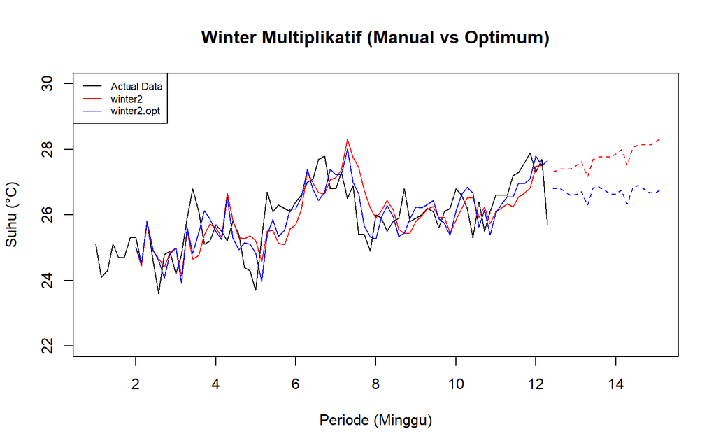

```r
plot(train_hw.ts, main = "Winter Multiplikatif (Manual vs Optimum)", type = "l", col = "black",
     xlim = c(1, 15), ylim = c(22, 30), xlab = "Periode (Minggu)", ylab = "Suhu (°C)")
lines(xhat2, type = "l", col = "red")
lines(xhat2.opt, type = "l", col = "blue")
lines(forecast2, type = "l", col = "red", lty = 2)
lines(forecast2.opt, type = "l", col = "blue", lty = 2)
legend("topleft", c("Actual Data", expression(paste(winter2)),
                   expression(paste(winter2.opt))), cex = 0.7,
       col = c("black", "red", "blue"), lty = 1)
```

#### 1.4.7.1 Akurasi Data Latih Winter Winter Multiplikatif

```r
SSE2 <- winter2$SSE
MSE2 <- winter2$SSE / length(train_hw.ts)
RMSE2 <- sqrt(MSE2)
akurasi2 <- matrix(c(SSE2, MSE2, RMSE2))
row.names(akurasi2) <- c("SSE2", "MSE2", "RMSE2")
colnames(akurasi2) <- c("Akurasi Winter 2")
akurasi2
```

```
##       Akurasi Winter 2
## SSE2        51.5915886
## MSE2         0.6448949
## RMSE2        0.8030535
```

```r
SSE2.opt <- winter2.opt$SSE
MSE2.opt <- winter2.opt$SSE / length(train_hw.ts)
RMSE2.opt <- sqrt(MSE2.opt)
akurasi2.opt <- matrix(c(SSE2.opt, MSE2.opt, RMSE2.opt))
row.names(akurasi2.opt) <- c("SSE2.opt", "MSE2.opt", "RMSE2.opt")
colnames(akurasi2.opt) <- c("Akurasi")
akurasi2.opt
```

```
##              Akurasi
## SSE2.opt  41.3838369
## MSE2.opt   0.5172980
## RMSE2.opt  0.7192343
```

```r
akurasi2.train = data.frame(Model_Winter = c("Winter 2", "Winter 2 optimal"),
                            Nilai_SSE = c(SSE2, SSE2.opt),
                            Nilai_MSE = c(MSE2, MSE2.opt),
                            Nilai_RMSE = c(RMSE2, RMSE2.opt))
akurasi2.train
```

| Model_Winter | Nilai_SSE | Nilai_MSE | Nilai_RMSE |
| --- | --- | --- | --- |
| Winter 2 | 51.59159 | 0.6448949 | 0.8030535 |
| Winter 2 optimal | 41.38384 | 0.5172980 | 0.7192343 |

#### 1.4.7.2 Akurasi Data Uji Winter Winter Multiplikatif

```r
# Akurasi Data Testing Winter Multiplikatif

forecast2_df <- data.frame(forecast2)
testing.ts_df <- data.frame(Yt = as.numeric(test_ma.ts))

selisih2 <- forecast2_df[, 1] - testing.ts_df$Yt
SSEtesting2 <- sum(selisih2^2)
MSEtesting2 <- SSEtesting2 / nrow(testing.ts_df)
MAPEtesting2 <- mean(abs(selisih2 / testing.ts_df$Yt) * 100)

forecast2.opt_df <- data.frame(forecast2.opt)
selisih2.opt <- forecast2.opt_df[, 1] - testing.ts_df$Yt
SSEtesting2.opt <- sum(selisih2.opt^2)
MSEtesting2.opt <- SSEtesting2.opt / nrow(testing.ts_df)
MAPEtesting2.opt <- mean(abs(selisih2.opt / testing.ts_df$Yt) * 100)

# Merapikan dalam tabel
akurasi_testing2 <- data.frame(
  Model = c("Model2", "Model2 Optimal"),
  SSE   = c(SSEtesting2, SSEtesting2.opt),
  MSE   = c(MSEtesting2, MSEtesting2.opt),
  MAPE  = c(MAPEtesting2, MAPEtesting2.opt)
)

akurasi_testing2
```

| Model | SSE | MSE | MAPE |
| --- | --- | --- | --- |
| Model2 | 35.93661 | 1.7968306 | 4.549451 |
| Model2 Optimal | 10.46813 | 0.5234063 | 2.346814 |